# Презентация по лабораторной работе №9

Командная оболочка Midnight Commander

Мориссала Д.

Российский университет дружбы народов, Москва, Россия

09 Апреля 2025

# Информация

## Докладчик

- Мориссала Донзо
- НКАбд 01-24
- Факультет физико-математический и естественных наук
- Российский университет дружбы народов
- 1032245982@rudn.ru
- https://Morissala.github.io/

# Задание по mc

Я запускала mc, изучала его структуру и меню:

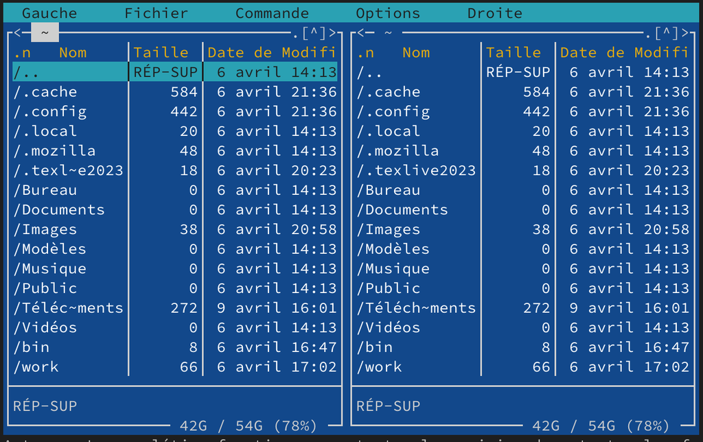

Командная оболочка mc

## Задание по mc

Используя управляющие клавиши я; скопировала файл README.md в домашний каталог:

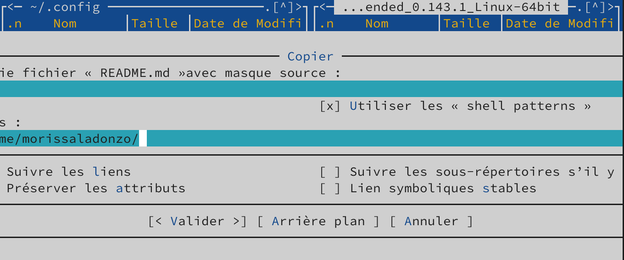

Копирование файла

## Задание по mc

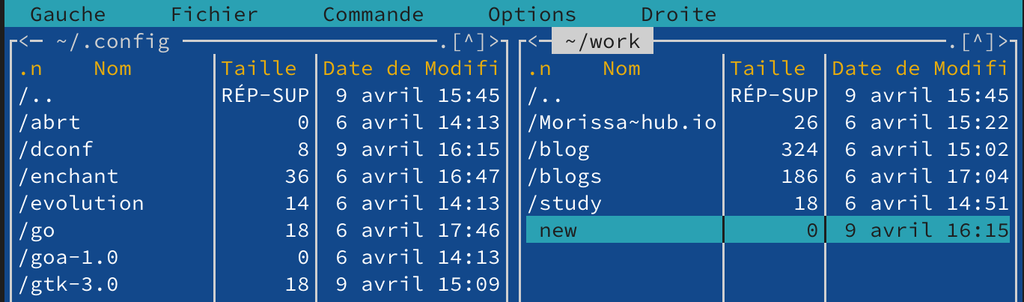

Созданный файл

## Задание по mc

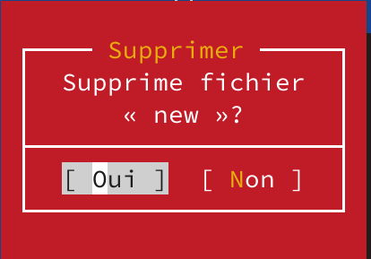

Удаление файла

## Задание по mc

Получила информацию о размере и правах доступа на файл README.md:

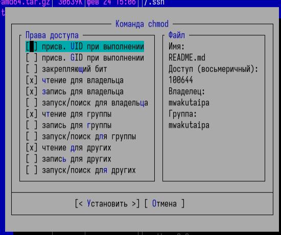

Информация о README.md

## Задание по mc

В правой панели вывела информацию о файле. При этом я получаю больше информации чем в выводе ls:

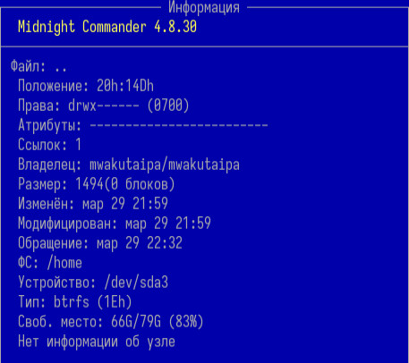

Информфцию о файле

## Задание по mc

Используя возможности подменю Файл; я посмотрела содержаемые текстового файла:

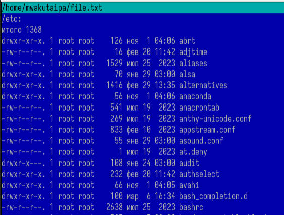

Содержаемые файла

## Задание по mc

редактировала содержаемые текстового файла (abrt на mi):

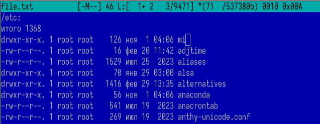

Редактирование файла

## Задание по mc

Создала новый каталог:

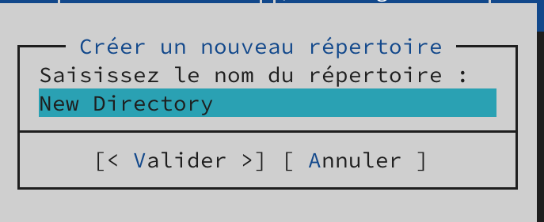

создание каталога

## Задание по mc

и скопировала файл в ,только что созданный каталог:

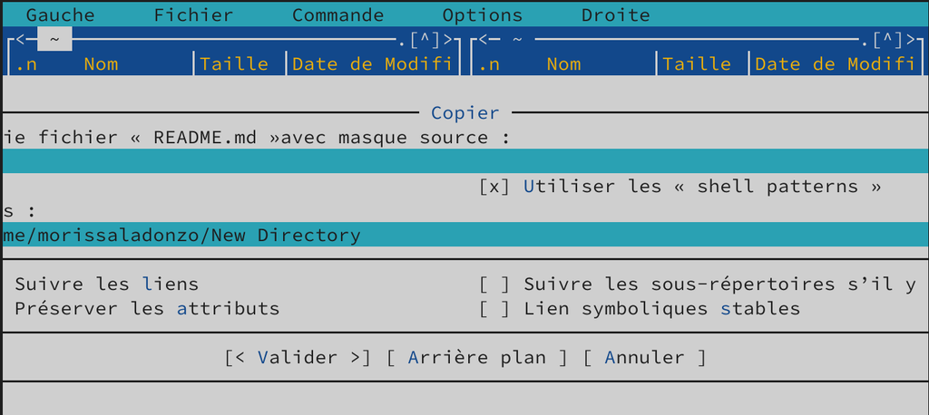

копирование файла

## Задание по mc

С помощью подменю команда можно найти в файловой системе файл с заданными условиями:

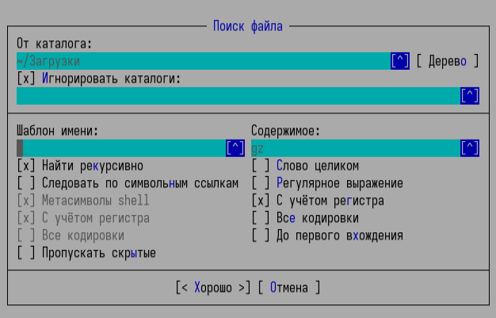

файлы которые содержат gz

## Задание по mc

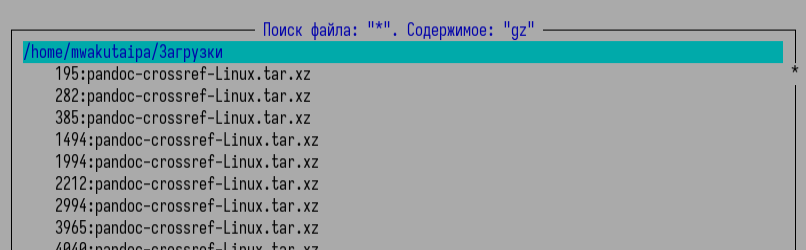

результаты поиска

## Задание по mc

Также перешла в домашний каталог и анализировала файл меню и файл расширения:

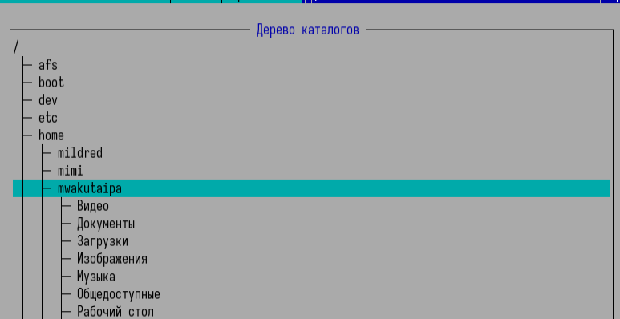

Переход в домашний каталог

## Задание по mc

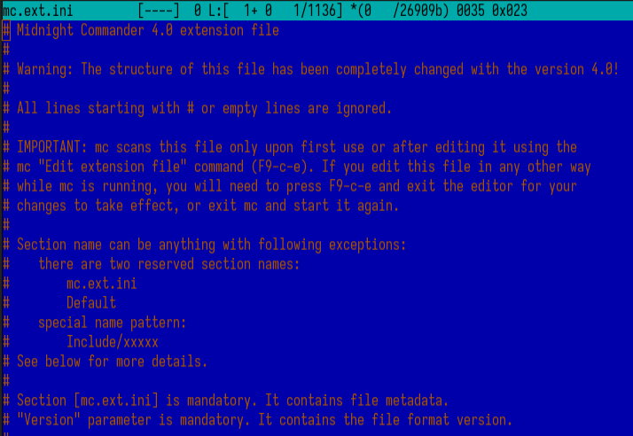

файл расширения

## Задание по mc

Из подменю настройка вызвала окна настройки панели:

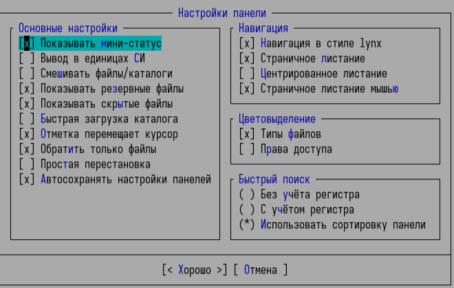

Настройка панели

## Задание по mc

Настройки внешнего вида:

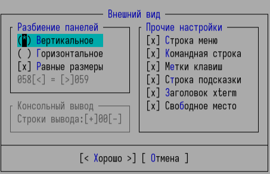

Настройки внешнего вида

# Задание по встроенному редактору mc

С помощью команды touch создала text.txt:

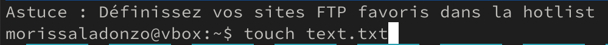

Создание text.txt

## Задание по встроенному редактору mc

Далее открыла его для редактирования с помощью f4 и с shift ctrl ins вставила текст:

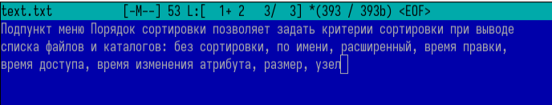

Редактирование text.txt

## Задание по встроенному редактору mc

С помощью f3 выделила текст и удалила выделеные слова f8:

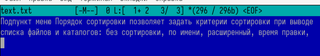

Удаление текста

## Задание по встроенному редактору mc

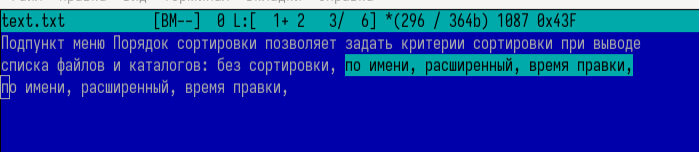

Перемещение текста

## Задание по встроенному редактору mc

Сохранила изменении с помощью f2:

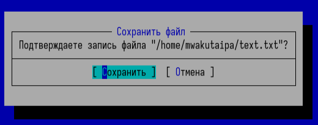

Сохранение изменений в файле

## Задание по встроенному редактору mc

С помощью ctrl-u отменила последнее действие:

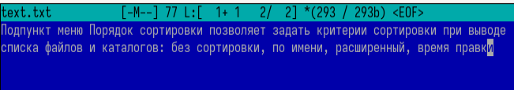

Отменение последнего действия

## Задание по встроенному редактору mc

Используя pg up и pg dn перешла в начало и конец файла и написала некоторый текст. Затем сохранила и закрыла файл:

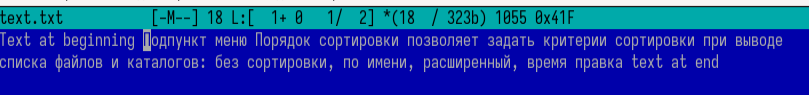

Добавление текста

## Задание по встроенному редактору mc

Открыла файл с исходным текстом на cpp:

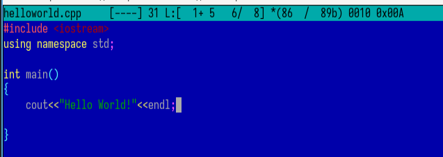

файл cpp

## Задание по встроенному редактору mc

Используя подменю команда я выключила подсветку синтаксиса:

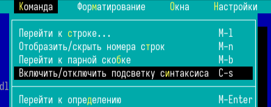

Подменю команда

## Задание по встроенному редактору mc

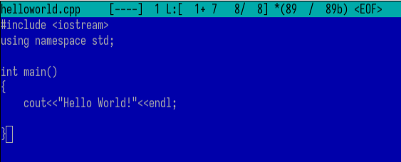

подсветка синтаксиса